# 9장

====================================================================================================  
**활용된 데이터**  
* 2015년 10차 한국복지패널조사-조사설계서-가구용(beta1)  
: 성별=23행 / 태어난 연도=24행 / 혼인상태=29행/ 종교=30행 / 월급=59행/지역= 10(5개권역),11(7개 권역)  
* 2015년 10차 한국복지패널조사-조사설계서-가구용(beta1) :직종= 직종코드시트2

**만든 변수 정리**: *언제 어떤 상황에서 왜 만들어졌는가.*

1.sex_income: 성별에 따른 월급차이 분석해서 성별 월급 평균표를 만들 때,  
전체에서 월급(income)만 필터링후, 성별로 그룹지어서 묶고 그 안에서 월급 평균을 산출하고 저장하기 위해서 만듬.

2.파생변수만들기:필요한 나이(age)변수를 birth변수 이용해서 계산해야함! =2015-출생연도+1

3.연령대별 월급 평균표만들기할 때 ageg_income, 그룹으로 묶어서 새로운 데이터프레임으로 만들기

4.sex_income, 연령대별로 그룹짓고 그 그룹내에서 성별로 그룹짓기  
연령대별로 구분하지 않고 나이 및 성별 월급 평균표 그래프만들 때,sex_age 성별 연령별 월급 평균표 만들기

5.welfare에 직업명 결합할 때, 원데이터(welfare)와 list_job에 code_job이라는 공통된 변수가 있다.

6.직업별 월급 상위10개 내림차순으로 정렬하기 위해 top10변수/ 월급하위10개 bottom10변수

7.이혼여부 변수 만들기:welfare$group_marriage  
혼인상태변수: 1번:유배우,3번:이혼만 남기고 제외하고 다 빼기

8.지역코드 목록 만들기 / 지역코드만 있으니 데이터로 만들어서 기존 데이터(welfare)에  
조인하기 위해 데이터 프레임형태로 만듬. list_region변수 / 지역명 순서 변수 만들기 order 변수

===========================================================================================  
###데이터 세팅

원본 데이터불러오기: 연습용 프로젝트라 시스템으로인해 오류남을 인지할 것!

```r
raw_welfare<-read.spss(file ="Koweps_hpc10_2015_beta1.sav",
                       to.data.frame = T)
```

원본데이터 복사본 만들기: 복구해야할 상황에 대비하기 위함!

```r
welfare<-raw_welfare
```

데이터 검토하기

```r
head(welfare)
tail(welfare)
View(welfare)
dim(welfare)
str(welfare)
summary(welfare)
```

변수명 쉬운 단어로 변경하기

```r
welfare<-rename(welfare,
                sex=h10_g3,        #성별
                birth=h10_g4,      #출생연도
                marriage=h10_g10,  #혼인상태
                religion=h10_g11,  #종교
                income=p1002_8aq1, #월급
                code_job=h10_eco9, #직종코드
                code_region=h10_reg7)#지역코드
```

### *데이터 분석 절차*

1.변수 검토 및 전처리 단계에서 *이상치* 검토!하고 있으면 결측처리 2.변수간 관계 분석

## 성별에 따른 월급차이

*필요변수: 성별, 월급(남자=1,여자=2)

### 1-1.성별 변수 검토 및 전처리

```r
class(welfare$sex)      #성별 변수 속성 확인
```

```
## [1] "numeric"
```

```r
table(welfare$sex)      #성별 변수 빈도 확인 및 이상치 확인
```

```
##
##    1    2
## 7578 9086
```

```r
welfare$sex<-ifelse(welfare$sex==9,NA,welfare$sex) #성별 변수 결측처리 (모름,무응답=9)

table(is.na(welfare$sex))  #성별 변수 결측치 확인
```

```
##
## FALSE
## 16664
```

```r
welfare$sex<-ifelse(welfare$sex==1,"male","female") #성별변수 항목 이름부여
table(welfare$sex)
```

```
##
## female   male
##   9086   7578
```

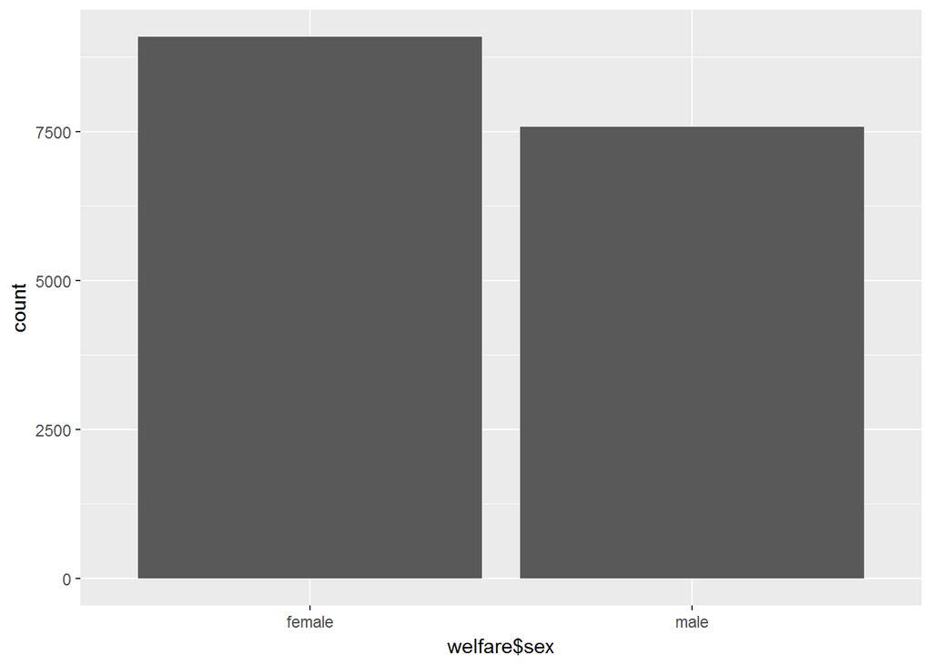

```r
qplot(welfare$sex)  #성별 그래프 그리기
```

### 1-2.월급변수 검토 및 전처리

```r
class(welfare$income)   #월급 변수 속성 확인
```

```
## [1] "numeric"
```

```r
summary(welfare$income)
```

```
##    Min. 1st Qu.  Median    Mean 3rd Qu.    Max.    NA's
##     0.0   122.0   192.5   241.6   316.6  2400.0   12030
```

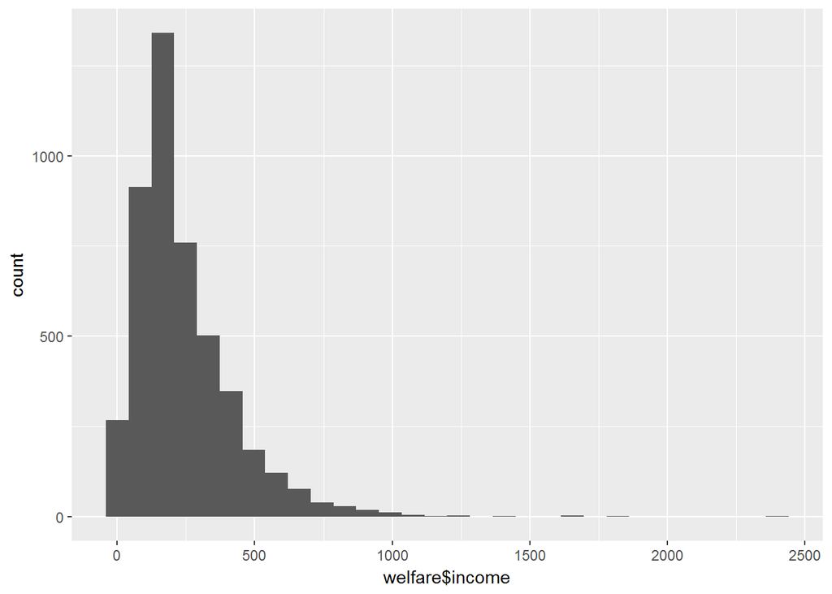

```r
qplot(welfare$income)
```

출력된 그래프를 보면 x축2500까지 있어서 0~1000사이의 데이터가 잘 표현되지 않음.-> xlim을 이용해서 설정 변경

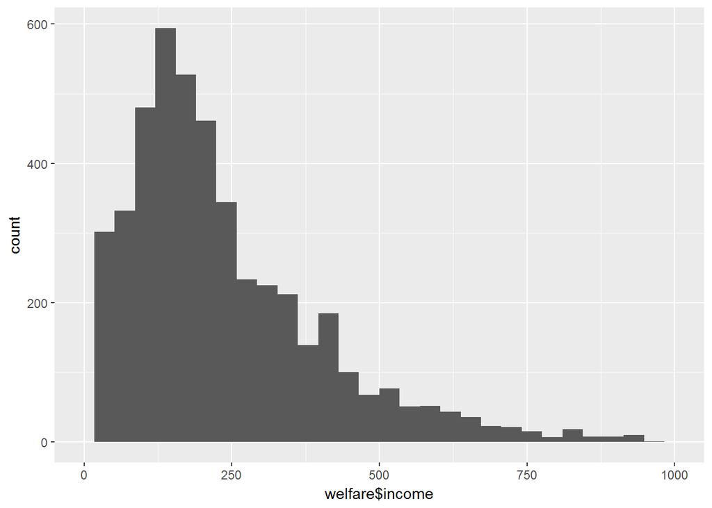

```r
qplot(welfare$income)+xlim(0,1000)
```

```r
summary(welfare$income) #월급 변수 이상치확인
```

```
##    Min. 1st Qu.  Median    Mean 3rd Qu.    Max.    NA's
##     0.0   122.0   192.5   241.6   316.6  2400.0   12030
```

```r
welfare$income<-ifelse(welfare$income%in% c(0,9999),NA,welfare$income) #이상치결측처리

table(is.na(welfare$income)) #결측치확인
```

```
##
## FALSE  TRUE
##  4620 12044
```

## 2.변수 간 관계분석

### 성별에 따른 월급차이 분석하기

```r
sex_income<-welfare %>% filter(!is.na(income))%>%group_by(sex)%>%
  summarise(mean_income=mean(income))
sex_income       #성별 월급 평균표
```

```
## # A tibble: 2 x 2
##   sex    mean_income
##   <chr>        <dbl>
## 1 female         163
## 2 male           312
```

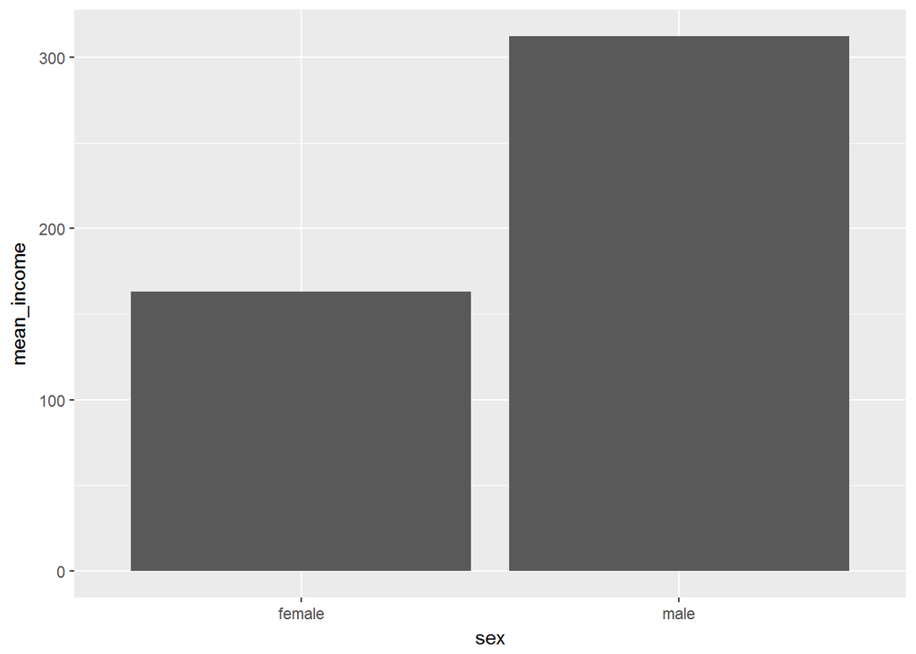

```r
ggplot(data=sex_income,aes(x=sex,y=mean_income))+geom_col() #그래프만들기
```

**그래프 결과**

남성의 월급이 여성의 월급보다 두배 높음.